# Deep Hit (part 2)

This notebook implements a DeepHit model for competing risks. It uses a single neural network to simultaneously predict the risk of death and readmission, explicitly modeling their competition. The model outputs Cumulative Incidence Functions (CIFs) for each risk, allowing evaluation of prediction accuracy over time for both outcomes using metrics like Uno’s C-Index (corrected for competing risks) and cause-specific Brier scores. It processes multiple imputed datasets and evaluates performance across different time horizons.

Author

ags

Published

February 11, 2026

## 0. Package loading and installation

```python
# Commented out IPython magic to ensure Python compatibility.
# For Jupyter/Colab notebooks
%reset -f
import gc
gc.collect()

import numpy as np
import pandas as pd
import time

#conda activate surv-deephit
#conda install ipykernel -y
#conda install -c conda-forge pytorch torchtuples pycox
#conda install pytorch torchvision torchaudio pytorch-cuda=11.8 -c pytorch -c nvidia
# conda install pycox torchtuples scikit-learn scikit-survival lifelines shap seaborn matplotlib scipy pandas -c conda-forge -y
# por si: conda install pycox torchtuples -c conda-forge -y

#Conda te avisa que va a hacer dos cambios porque estás instalando PyTorch con CUDA:
#conda-forge::cuda-cudart 12.9  →  nvidia::cuda-cudart 11.8

#Packages stored in :
#conda env export --no-builds > "G:\My Drive\Alvacast\SISTRAT 2023\dh\environment.yml"

#Load packages in:
#conda activate base
# conda install -c conda-forge conda-lock
#conda env export --no-builds | findstr /V "^prefix:" > "G:\My Drive\Alvacast\SISTRAT 2023\dh\environment.yml"

import sys
import subprocess

import pandas as pd
import numpy as np
import matplotlib.pyplot as plt

import numpy as np
import pandas as pd
import torch
import matplotlib.pyplot as plt
from sklearn.preprocessing import StandardScaler
from sklearn.model_selection import train_test_split

# Check device
device = 'cuda' if torch.cuda.is_available() else 'cpu'
print(f"✅ Compute Device: {device}")

from sksurv.metrics import (
    concordance_index_ipcw,
    brier_score,
    integrated_brier_score
)
from sksurv.util import Surv



#Glimpse function
def glimpse(df, max_width=80):
    print(f"Rows: {df.shape[0]} | Columns: {df.shape[1]}")
    for col in df.columns:
        dtype = df[col].dtype
        preview = df[col].astype(str).head(5).tolist()
        preview_str = ", ".join(preview)
        if len(preview_str) > max_width:
            preview_str = preview_str[:max_width] + "..."
        print(f"{col:<30} {str(dtype):<15} {preview_str}")
#Tabyl function
def tabyl(series):
    counts = series.value_counts(dropna=False)
    props = series.value_counts(normalize=True, dropna=False)
    return pd.DataFrame({"value": counts.index,
                         "n": counts.values,
                         "percent": props.values})
#clean_names
import re

def clean_names(df):
    """
    Mimic janitor::clean_names for pandas DataFrames.
    - Lowercase
    - Replace spaces and special chars with underscores
    - Remove non-alphanumeric/underscore
    """
    new_cols = []
    for col in df.columns:
        # lowercase
        col = col.lower()
        # replace spaces and special chars with underscore
        col = re.sub(r"[^\w]+", "_", col)
        # strip leading/trailing underscores
        col = col.strip("_")
        new_cols.append(col)
    df.columns = new_cols
    return df
```

```
✅ Compute Device: cuda
```

```python
packages = ["torch", "torchtuples", "pycox"]

for p in packages:
    try:
        mod = __import__(p)
        print(f"✅ {p} installed | version:", getattr(mod, "__version__", "unknown"))
    except ImportError:
        print(f"❌ {p} NOT installed")
```

```
✅ torch installed | version: 2.5.1
✅ torchtuples installed | version: 0.2.2
✅ pycox installed | version: 0.3.0
```

## Load data

```python
from pathlib import Path

BASE_DIR = Path(
    r"G:\My Drive\Alvacast\SISTRAT 2023\data\20241015_out\pred1"
)


import pickle

with open(BASE_DIR / "imputations_list_jan26.pkl", "rb") as f:
    imputations_list_jan26 = pickle.load(f)


imputation_nodum_1 = pd.read_parquet(
    BASE_DIR / "imputation_nondum_1.parquet",
    engine="fastparquet"
)

X_reduced_imp0 = pd.read_parquet(
    BASE_DIR / "X_reduced_imp0.parquet",
    engine="fastparquet"
)

imputation_1 = pd.read_parquet(
    BASE_DIR / "imputation_1.parquet",
    engine="fastparquet"
)


# Quick check
glimpse(imputation_nodum_1)
glimpse(imputation_1)
glimpse(X_reduced_imp0)
```

```
Rows: 88504 | Columns: 43
readmit_time_from_adm_m        float64         84.93548387096774, 12.833333333333334, 13.733333333333333, 11.966666666666667, 1...
death_time_from_adm_m          float64         84.93548387096774, 87.16129032258064, 117.2258064516129, 98.93548387096774, 37.9...
adm_age_rec3                   float64         31.53, 20.61, 42.52, 60.61, 45.08
porc_pobr                      float64         0.175679117441177, 0.187835901975632, 0.130412444472313, 0.133759185671806, 0.08...
dit_m                          float64         15.967741935483872, 5.833333333333334, 0.4752688172043005, 6.966666666666667, 6....
sex_rec                        object          man, man, man, woman, man
tenure_status_household        object          stays temporarily with a relative, owner/transferred dwellings/pays dividends, s...
cohabitation                   object          alone, family of origin, with couple/children, with couple/children, family of o...
sub_dep_icd10_status           object          drug dependence, hazardous consumption, drug dependence, drug dependence, drug d...
any_violence                   object          0.No domestic violence/sex abuse, 0.No domestic violence/sex abuse, 0.No domesti...
prim_sub_freq_rec              object          2.2–6 days/wk, 3.Daily, 3.Daily, 3.Daily, 3.Daily
tr_outcome                     object          referral, dropout, adm discharge - rule violation/undet, dropout, completion
adm_motive                     object          sanitary sector, spontaneous consultation, sanitary sector, sanitary sector, spo...
first_sub_used                 object          alcohol, alcohol, alcohol, cocaine paste, alcohol
primary_sub_mod                object          alcohol, cocaine paste, cocaine paste, cocaine paste, cocaine paste
tipo_de_vivienda_rec2          object          other/unknown, formal housing, formal housing, formal housing, formal housing
national_foreign               int32           0, 0, 0, 0, 0
plan_type_corr                 object          pg-pab, pg-pab, pg-pr, m-pr, pg-pai
occupation_condition_corr24    object          unemployed, employed, employed, inactive, unemployed
marital_status_rec             object          single, single, single, married/cohabiting, single
urbanicity_cat                 object          3.Urban, 3.Urban, 3.Urban, 3.Urban, 3.Urban
ed_attainment_corr             object          2-Completed high school or less, 3-Completed primary school or less, 2-Completed...
evaluacindelprocesoteraputico  object          logro alto, logro minimo, logro minimo, logro minimo, logro alto
eva_consumo                    object          logro alto, logro minimo, logro minimo, logro intermedio, logro alto
eva_fam                        object          logro intermedio, logro minimo, logro minimo, logro intermedio, logro alto
eva_relinterp                  object          logro alto, logro minimo, logro minimo, logro intermedio, logro alto
eva_ocupacion                  object          logro alto, logro minimo, logro minimo, logro minimo, logro intermedio
eva_sm                         object          logro intermedio, logro minimo, logro minimo, logro intermedio, logro minimo
eva_fisica                     object          logro alto, logro minimo, logro intermedio, logro intermedio, logro alto
eva_transgnorma                object          logro alto, logro minimo, logro minimo, logro minimo, logro intermedio
ethnicity                      float64         0.0, 0.0, 0.0, 0.0, 0.0
dg_psiq_cie_10_instudy         bool            False, False, True, False, False
dg_psiq_cie_10_dg              bool            True, False, False, True, False
dx_f3_mood                     int32           0, 0, 0, 0, 0
dx_f6_personality              int32           0, 0, 0, 1, 0
dx_f_any_severe_mental         bool            True, False, False, False, False
any_phys_dx                    bool            False, False, False, True, False
polysubstance_strict           int32           0, 1, 1, 1, 1
readmit_event                  float64         0.0, 1.0, 1.0, 1.0, 1.0
```

[output cut: 192 more lines]

```
eva_sm_logro intermedio        bool            True, False, False, True, False
eva_sm_logro minimo            bool            False, True, True, False, True
eva_fisica_logro alto          bool            True, False, False, False, True
eva_fisica_logro intermedio    bool            False, False, True, True, False
eva_fisica_logro minimo        bool            False, True, False, False, False
eva_transgnorma_logro alto     bool            True, False, False, False, False
eva_transgnorma_logro intermedio bool            False, False, False, False, True
eva_transgnorma_logro minimo   bool            False, True, True, True, False
adm_age_cat_30-44              bool            True, False, True, False, False
adm_age_cat_45-64              bool            False, False, False, True, True
nationality_chile_other        bool            False, False, False, False, False
plan_type_corr_m-pr            bool            False, False, False, True, False
plan_type_corr_pg-pab          bool            True, True, False, False, False
plan_type_corr_pg-pai          bool            False, False, False, False, True
plan_type_corr_pg-pr           bool            False, False, True, False, False
```

Load in python

```python
if isinstance(imputations_list_jan26, list) and len(imputations_list_jan26) > 0:
    print("First element type:", type(imputations_list_jan26[0]))
    if isinstance(imputations_list_jan26[0], dict):
        print("First element keys:", imputations_list_jan26[0].keys())
    elif isinstance(imputations_list_jan26[0], (pd.DataFrame, np.ndarray)):
        print("First element shape:", imputations_list_jan26[0].shape)
```

```
First element type: <class 'pandas.core.frame.DataFrame'>
First element shape: (88504, 56)
```

This code block:

1. **Imports the `pickle` library**: This library implements binary protocols for serializing and de-serializing a Python object structure.
2. **Specifies the `file_path`**: It points to the `.pkl` file you selected.
3. **Opens the file in binary read mode (`'rb'`)**: This is necessary for loading pickle files.
4. **Loads the object**: `pickle.load(f)` reads the serialized object from the file and reconstructs it in memory.
5. **Prints confirmation and basic information**: It verifies that the file was loaded and shows the type of the loaded object, and some details about the first element if it’s a list containing common data structures.

#### Compare databases (transformed and original)

Inspect and compare the column names of two datasets: the first imputation from imputations_list_jan26 (which likely contains dummy variables) and imputation_nodum_1 (which, as its name suggests, probably doesn’t have dummy variables).

```python
# Inspect columns of the first imputation
cols_first_imp = imputations_list_jan26[0].columns.tolist()
print("First imputation columns:", cols_first_imp[:10], "... total:", len(cols_first_imp))

# Inspect columns of imputation_no_dum
cols_nodum = imputation_nodum_1.columns.tolist()
print("No-dum columns:", cols_nodum[:10], "... total:", len(cols_nodum))

# Compare overlap
common_cols = set(cols_first_imp).intersection(cols_nodum)
missing_in_imp = [c for c in cols_nodum if c not in cols_first_imp]
missing_in_nodum = [c for c in cols_first_imp if c not in cols_nodum]

print("Common columns:", len(common_cols))
print("Missing in imputations_list_jan26:", missing_in_imp)

# Inspect columns of the first imputation
cols_first_imp_raw = imputation_1.columns.tolist()
print("First imputation columns:", cols_first_imp_raw[:10], "... total:", len(cols_first_imp_raw))

# Compare overlap
common_cols_raw = set(cols_first_imp_raw).intersection(cols_nodum)
missing_in_imp_raw = [c for c in cols_nodum if c not in cols_first_imp_raw]

print("Common columns:", len(common_cols_raw))
print("Missing in imputations_list_jan26:", missing_in_imp_raw)
print(common_cols_raw)

import pandas as pd

# Example: choose a combination of variables that uniquely identify rows
key_vars = ["adm_age_rec3", "porc_pobr", "dit_m"]

# Take one imputation (first element of the list) and merge with the no-dum dataset
df_imp = imputations_list_jan26[0]
df_nodum = imputation_nodum_1

merged_check = pd.merge(
    df_imp[key_vars],
    df_nodum[key_vars],
    on=key_vars,
    how="inner"
)

print(f"Merged rows: {merged_check.shape[0]}")
print("Preview of merged check:")
print(merged_check.head())

#drop merge
del merged_check

import pandas as pd

# Example: choose a combination of variables that uniquely identify rows
key_vars_raw = ['dit_m',
            'readmit_time_from_adm_m',
            'death_time_from_adm_m',
            'adm_age_rec3']
# Take one imputation (first element of the list) and merge with the no-dum dataset
df_raw = imputation_1

merged_check_raw = pd.merge(
    df_imp[key_vars],
    df_raw[key_vars],
    on=key_vars,
    how="inner"
)

print(f"Merged rows: {merged_check_raw.shape[0]}")
print("Preview of merged check:")
print(merged_check_raw.head())
print(f"{(merged_check_raw.shape[0] / imputation_1.shape[0] * 100):.2f}%")
#drop merge
del merged_check_raw
```

```
First imputation columns: ['adm_age_rec3', 'porc_pobr', 'dit_m', 'tenure_status_household', 'prim_sub_freq_rec', 'national_foreign', 'urbanicity_cat', 'ed_attainment_corr', 'evaluacindelprocesoteraputico', 'eva_consumo'] ... total: 56
No-dum columns: ['readmit_time_from_adm_m', 'death_time_from_adm_m', 'adm_age_rec3', 'porc_pobr', 'dit_m', 'sex_rec', 'tenure_status_household', 'cohabitation', 'sub_dep_icd10_status', 'any_violence'] ... total: 43
Common columns: 24
Missing in imputations_list_jan26: ['readmit_time_from_adm_m', 'death_time_from_adm_m', 'sex_rec', 'cohabitation', 'sub_dep_icd10_status', 'any_violence', 'tr_outcome', 'adm_motive', 'first_sub_used', 'primary_sub_mod', 'tipo_de_vivienda_rec2', 'plan_type_corr', 'occupation_condition_corr24', 'marit…
First imputation columns: ['readmit_time_from_adm_m', 'death_time_from_adm_m', 'adm_age_rec3', 'porc_pobr', 'dit_m', 'national_foreign', 'ethnicity', 'dg_psiq_cie_10_instudy', 'dg_psiq_cie_10_dg', 'dx_f3_mood'] ... total: 78
Common columns: 18
Missing in imputations_list_jan26: ['sex_rec', 'tenure_status_household', 'cohabitation', 'sub_dep_icd10_status', 'any_violence', 'prim_sub_freq_rec', 'tr_outcome', 'adm_motive', 'first_sub_used', 'primary_sub_mod', 'tipo_de_vivienda_rec2', 'plan_type_corr', 'occupation_condition_corr24', 'marital_s…
{'death_event', 'readmit_time_from_disch_m', 'any_phys_dx', 'dx_f_any_severe_mental', 'dx_f3_mood', 'dg_psiq_cie_10_instudy', 'polysubstance_strict', 'dg_psiq_cie_10_dg', 'national_foreign', 'dit_m', 'porc_pobr', 'dx_f6_personality', 'death_time_from_disch_m', 'readmit_event', 'ethnicity', 'death_ti…
Merged rows: 88516
Preview of merged check:
   adm_age_rec3  porc_pobr      dit_m
0         31.53   0.175679  15.967742
1         20.61   0.187836   5.833333
2         42.52   0.130412   0.475269
3         60.61   0.133759   6.966667
4         45.08   0.083189   6.903226
Merged rows: 88516
Preview of merged check:
   adm_age_rec3  porc_pobr      dit_m
0         31.53   0.175679  15.967742
1         20.61   0.187836   5.833333
2         42.52   0.130412   0.475269
3         60.61   0.133759   6.966667
4         45.08   0.083189   6.903226
100.01%
```

### Create bins for followup (landmarks)

This code prepares your data for survival analysis. It extracts the time until an event (like readmission or death) and whether that event actually happened for each patient from the df_nodum dataset. Then, it automatically creates a set of important time points, called an ‘evaluation grid’, which are specific moments to assess the model’s performance on both readmission and death outcomes.

```python
import numpy as np

# Required columns for survival outcomes
required = ["readmit_time_from_disch_m", "readmit_event",
            "death_time_from_disch_m", "death_event"]

# Check that df_raw has all required columns
missing = [c for c in required if c not in df_raw.columns]
if missing:
    raise KeyError(f"df_nodum is missing columns: {missing}")

# Create time/event arrays directly from df_raw
time_readm = df_raw["readmit_time_from_adm_m"].to_numpy()
event_readm = (df_raw["readmit_event"].to_numpy() == 1)

time_death = df_raw["death_time_from_adm_m"].to_numpy()
event_death = (df_nodum["death_event"].to_numpy() == 1)

print("Arrays created for df_raw:")
print("Readmission times:", time_readm[:5])
print("Readmission events:", event_readm[:5])
print("Death times:", time_death[:5])
print("Death events:", event_death[:5])

# Build evaluation grids (quantiles of event times)
event_times_readm = time_readm[event_readm]
event_times_death = time_death[event_death]

if len(event_times_readm) < 5 or len(event_times_death) < 5:
    raise ValueError("Too few events in df_raw to build reliable time grids.")

times_eval_readm = np.unique(np.quantile(event_times_readm, np.linspace(0.05, 0.95, 50)))
times_eval_death = np.unique(np.quantile(event_times_death, np.linspace(0.05, 0.95, 50)))

print("Eval times (readmission):", times_eval_readm[:5], "...", times_eval_readm[-5:])
print("Eval times (death):", times_eval_death[:5], "...", times_eval_death[-5:])
```

```
Arrays created for df_raw:
Readmission times: [84.93548387 12.83333333 13.73333333 11.96666667 14.25806452]
Readmission events: [False  True  True  True  True]
Death times: [ 84.93548387  87.16129032 117.22580645  98.93548387  37.93548387]
Death events: [False False False False False]
Eval times (readmission): [3.93548387 4.77419355 5.45058701 6.06492649 6.67741935] ... [54.44173469 58.41566162 63.23333333 68.54767171 74.68983871]
Eval times (death): [4.16290323 5.43022383 6.68564845 8.24254115 9.77961817] ... [81.92700461 85.41186103 88.78518762 93.5538183  99.21935484]
```

Prepare survival data

```python
import numpy as np

# Step 1. Extract survival outcomes directly from df_raw
time_readm = df_raw["readmit_time_from_adm_m"].to_numpy()
event_readm = (df_raw["readmit_event"].to_numpy() == 1)

time_death = df_raw["death_time_from_adm_m"].to_numpy()
event_death = (df_raw["death_event"].to_numpy() == 1)

# Step 2. Build structured arrays (Surv objects)
y_surv_readm = np.empty(len(time_readm), dtype=[("event", "?"), ("time", "<f8")])
y_surv_readm["event"] = event_readm
y_surv_readm["time"] = time_readm

y_surv_death = np.empty(len(time_death), dtype=[("event", "?"), ("time", "<f8")])
y_surv_death["event"] = event_death
y_surv_death["time"] = time_death

# Step 3. Replicate across imputations
n_imputations = len(imputations_list_jan26)
y_surv_readm_list = [y_surv_readm for _ in range(n_imputations)]
y_surv_death_list = [y_surv_death for _ in range(n_imputations)]
```

## PyCox

Competing-risk outcomes were constructed using a time-to-first-event formulation, where readmission was coded as the event of interest if it occurred before death, and death was treated as the competing event otherwise. This ensured correct handling of event ordering and avoided misclassification of earlier readmissions as deaths. Although patients may experience multiple clinical events over follow-up, competing-risk survival models are defined on time to first event only; subsequent events are therefore outside the estimand rather than discarded.

### First attempt

```python
#@title ⚡ Final Comprehensive Evaluation: Pooled DeepHit (Strict No-Leakage)
import torch
import torch.nn as nn
import numpy as np
import pandas as pd
import shap
import time
import gc
import warnings
from datetime import datetime
from sklearn.model_selection import StratifiedKFold
from sklearn.preprocessing import StandardScaler
from sklearn.metrics import roc_auc_score, f1_score, precision_score, recall_score, confusion_matrix
from sksurv.metrics import concordance_index_ipcw, brier_score, integrated_brier_score
from pycox.models import DeepHit
from pycox.preprocessing.label_transforms import LabTransDiscreteTime
import torchtuples as tt
import matplotlib.pyplot as plt
from lifelines import KaplanMeierFitter

start_time = time.time()

TEST_MODE = False

# --- 1. CONFIGURATION ---
BEST_LR = 0.001
BEST_WD = 0.001
BEST_BATCH = 1024
BEST_DROPOUT = 0.5
BEST_NODES = [256, 256, 128]
BEST_ALPHA = 0.5
BEST_SIGMA = 0.5

NUM_RISKS = 3
K_FOLDS = 10
EVAL_HORIZONS = [3, 6, 12, 24, 36, 48, 60, 72, 84, 96, 108]
DEVICE = 'cuda' if torch.cuda.is_available() else 'cpu'

# Assuming imputations_list_jan26 is a list of 5 DataFrames
N_IMPUTATIONS = len(imputations_list_jan26)

#Check if test mode, and modify parameters accordingly
if TEST_MODE:
    N_IMPUTATIONS_TEST = 1
    K_FOLDS_TEST = 5
    EVAL_HORIZONS_TEST = [12, 24]
    MAX_EPOCHS_TEST = 30
    SHAP_FOLDS_TEST = 2
else:
    N_IMPUTATIONS_TEST = N_IMPUTATIONS
    K_FOLDS_TEST = K_FOLDS
    EVAL_HORIZONS_TEST = EVAL_HORIZONS
    MAX_EPOCHS_TEST = 100
    SHAP_FOLDS_TEST = 3

warnings.filterwarnings("ignore")

print(f"⚡ Starting Pooled Evaluation on {N_IMPUTATIONS_TEST} Imputations...")
print(f"   Device: {DEVICE} | Horizons: {EVAL_HORIZONS_TEST}")

# --- 2. NETWORK CLASS ---
class CauseSpecificNet(nn.Module):
    def __init__(self, in_f, nodes, out_f, dropout, num_risks):
        super().__init__()
        self.net = tt.practical.MLPVanilla(in_f, nodes, out_f, batch_norm=True, dropout=dropout)
        self.num_risks = num_risks
    def forward(self, x):
        return self.net(x).view(x.size(0), self.num_risks, -1)

# --- 3. METRIC HELPERS ---
def get_binary_target(events, times, risk_id, t_horizon):
    # Target: 1 if Event_k <= t, 0 otherwise (excluding censored before t)
    is_case = (events == risk_id) & (times <= t_horizon)
    mask_censored_early = (events == 0) & (times <= t_horizon)
    valid_mask = ~mask_censored_early
    y_binary = is_case[valid_mask].astype(int)
    return y_binary, valid_mask

def find_optimal_threshold(y_true, y_prob):
    # Optimizes F1 on TRAINING data
    thresholds = np.linspace(0.01, 0.99, 99)
    best_f1 = -1
    best_th = 0.5
    for th in thresholds:
        y_pred = (y_prob >= th).astype(int)
        f1 = f1_score(y_true, y_pred, zero_division=0)
        if f1 > best_f1:
            best_f1 = f1
            best_th = th
    return best_th

def calculate_binary_metrics(y_true, y_prob, fixed_threshold):
    # Applies FIXED threshold to TEST data
    y_pred = (y_prob >= fixed_threshold).astype(int)
    tn, fp, fn, tp = confusion_matrix(y_true, y_pred).ravel()

    return {
        'F1': f1_score(y_true, y_pred, zero_division=0),
        'Sens': recall_score(y_true, y_pred, zero_division=0),
        'Spec': tn / (tn + fp) if (tn + fp) > 0 else 0,
        'PPV': precision_score(y_true, y_pred, zero_division=0),
        'NPV': tn / (tn + fn) if (tn + fn) > 0 else 0,
        'Threshold': fixed_threshold
    }

def bootstrap_ci_non_normal(data, alpha=0.05):
    if len(data) < 2: return np.mean(data), np.mean(data), np.mean(data)
    lower = np.percentile(data, 100 * (alpha / 2))
    upper = np.percentile(data, 100 * (1 - alpha / 2))
    return np.mean(data), lower, upper

def compute_brier_competing(cif_values_at_time_horizon, censoring_kmf,
                            Y_test, D_test, event_of_interest, time_horizon):
    n = len(Y_test)
    assert len(D_test) == n

    residuals = np.zeros(n)
    for idx in range(n):
        observed_time = Y_test[idx]
        event_indicator = D_test[idx]
        if observed_time > time_horizon:
            weight = censoring_kmf.predict(time_horizon)
            residuals[idx] = (cif_values_at_time_horizon[idx])**2 / weight
        else:
            weight = censoring_kmf.predict(observed_time)
            if event_indicator == event_of_interest:
                residuals[idx] = (1 - cif_values_at_time_horizon[idx])**2 / weight
            elif event_indicator != event_of_interest and event_indicator != 0:
                residuals[idx] = (cif_values_at_time_horizon[idx])**2 / weight
    return residuals.mean()

# --- 4. MAIN POOLED LOOP ---
pooled_results = []
shap_samples_agg = []
shap_values_agg = []

start_time_global = time.time()

for imp_idx in range(N_IMPUTATIONS_TEST):
    print(f"\n📚 Imputation {imp_idx + 1}/{N_IMPUTATIONS_TEST}")

    # Load Data
    X_raw = imputations_list_jan26[imp_idx]
    y_d = y_surv_death_list[imp_idx]
    y_r = y_surv_readm_list[imp_idx]

    # Pre-process
    t_d = np.asarray(y_d['time'])
    e_d = np.asarray(y_d['event']).astype(bool)

    t_r = np.asarray(y_r['time'])
    e_r = np.asarray(y_r['event']).astype(bool)

    events = np.zeros(len(X_raw), dtype=int)
    times  = t_d.copy().astype('float32')  # default = death/censor time

    # Readmission happens first
    mask_r = e_r & (t_r <= t_d)
    events[mask_r] = 2
    times[mask_r]  = t_r[mask_r]

    # Death happens first (or only)
    mask_d = e_d & (~mask_r)
    events[mask_d] = 1
    # times already = t_d
    print("Event counts:", np.bincount(events))

    # Stratification
    X_curr = X_raw.copy()
    plan_cols = [c for c in X_raw.columns if c.startswith("plan_type_corr")]
    X_curr[plan_cols] = X_curr[plan_cols].astype('float32')
    #✅ Step 1: define an explicit plan index mapping
    plan_idx = np.zeros(len(X_curr), dtype=int)  # 0 = pg_pab (reference)
    if 'plan_type_corr_pg_pr' in X_curr.columns:
        plan_idx[X_curr['plan_type_corr_pg_pr'] == 1] = 1
    if 'plan_type_corr_m_pr' in X_curr.columns:
        plan_idx[X_curr['plan_type_corr_m_pr'] == 1] = 2
    if 'plan_type_corr_pg_pai' in X_curr.columns:
        plan_idx[X_curr['plan_type_corr_pg_pai'] == 1] = 3
    if 'plan_type_corr_m_pai' in X_curr.columns:
        plan_idx[X_curr['plan_type_corr_m_pai'] == 1] = 4
    # Exactly one plan must be true per row
    plan_sum = X_curr[plan_cols].sum(axis=1)
```

```python
    if (plan_sum > 1).all():
        raise ValueError("Invalid plan encoding: some rows have >1 plan types.")
    #✅ Step 2: combine with competing-risk event for stratification
    strat_labels = (events * 10) + plan_idx

    # CV Loop
    skf = StratifiedKFold(n_splits=K_FOLDS_TEST, shuffle=True, random_state=2125 + imp_idx) # Vary seed per imp

    for fold_idx, (train_idx, val_idx) in enumerate(skf.split(X_curr, strat_labels)):
        print(f".", end="")

        X_train, X_val = X_curr.iloc[train_idx].values, X_curr.iloc[val_idx].values
        t_train, e_train = times[train_idx], events[train_idx]
        t_val, e_val = times[val_idx], events[val_idx]

        # Scale
        scaler = StandardScaler().fit(X_train)
        X_train_s = scaler.transform(X_train).astype('float32')
        X_val_s = scaler.transform(X_val).astype('float32')

        # Discretize
        labtrans = LabTransDiscreteTime(100)
        y_train = labtrans.fit_transform(t_train, e_train)
        y_val = labtrans.transform(t_val, e_val)
        y_train = (y_train[0].astype('int64'), y_train[1].astype('int64'))
        y_val = (y_val[0].astype('int64'), y_val[1].astype('int64'))

        # Train
        in_f = X_train.shape[1]
        out_f = labtrans.out_features * NUM_RISKS
        net = CauseSpecificNet(in_f, BEST_NODES, out_f, BEST_DROPOUT, NUM_RISKS)
        model = DeepHit(net, tt.optim.Adam, alpha=BEST_ALPHA, sigma=BEST_SIGMA, duration_index=labtrans.cuts)
        model.set_device(DEVICE)
        model.optimizer.set_lr(BEST_LR)
        model.optimizer.param_groups[0]['weight_decay'] = BEST_WD

        model.fit(X_train_s, y_train, batch_size=BEST_BATCH, epochs=MAX_EPOCHS_TEST,
                  callbacks=[tt.callbacks.EarlyStopping()], verbose=False, val_data=(X_val_s, y_val))

        # Predict (Test)
        cif_val = model.predict_cif(X_val_s)

        # Predict (Train - for threshold tuning)
        cif_train = model.predict_cif(X_train_s)

        # --- SHAP (Imp 1 only to save space) ---
        if imp_idx == 0 and fold_idx < SHAP_FOLDS_TEST:
            try:
                bg = X_train_s[np.random.choice(len(X_train_s), 50, replace=False)]
                test = X_val_s[np.random.choice(len(X_val_s), 50, replace=False)]
                def pred_risk_24m(x): # Combined Risk Driver
                    x_t = torch.from_numpy(x).to(DEVICE)
                    with torch.no_grad():
                        c = model.predict_cif(x_t)
                        i = np.searchsorted(model.duration_index, 24)
                        return (c[1][i,:] + c[2][i,:]).cpu().numpy()
                ex = shap.KernelExplainer(pred_risk_24m, bg)
                shap_values_agg.append(ex.shap_values(test, nsamples=50, silent=True))
                shap_samples_agg.append(test)
            except: pass

        # --- METRICS ---
        outcomes_map = {1: 'Death', 2: 'Readmission'}

        # Structures for IPCW
        y_tr_st = np.array([(bool(e!=0), t) for e, t in zip(e_train, t_train)], dtype=[('e', bool), ('t', float)])
        y_va_st = np.array([(bool(e!=0), t) for e, t in zip(e_val, t_val)], dtype=[('e', bool), ('t', float)])

        # Censoring model (G-hat)
        # Event = 1 if censored, 0 otherwise
        censoring_kmf = KaplanMeierFitter()
        censoring_kmf.fit(
            t_train,
            event_observed=(e_train == 0).astype(int)
        )

        for risk_id, outcome_name in outcomes_map.items():
            # Cause-Specific Structures
            y_tr_cs = np.array([(bool(e==risk_id), t) for e, t in zip(e_train, t_train)], dtype=[('e', bool), ('t', float)])
            y_va_cs = np.array([(bool(e==risk_id), t) for e, t in zip(e_val, t_val)], dtype=[('e', bool), ('t', float)])

            # 1. Global Metrics
            # Corrected: Use Integral of CIF as global risk score
            # Simply summing CIF over all time points approximates the integral
            risk_score_global = cif_val[risk_id].sum(axis=0)

            try:
                uno_g = concordance_index_ipcw(y_tr_cs, y_va_cs, risk_score_global)[0]
            except Exception:
                uno_g = np.nan

            pooled_results.append({'Imp': imp_idx, 'Fold': fold_idx, 'Outcome': outcome_name, 'Time': 'Global', 'Metric': 'Uno C-Index', 'Value': uno_g})

            # 2. Time-Dependent Metrics
            for t in EVAL_HORIZONS_TEST:
                idx_t = np.searchsorted(model.duration_index, t)
                if idx_t >= len(model.duration_index): idx_t = len(model.duration_index) - 1

                # Risk Scores
                risk_t_val = cif_val[risk_id][idx_t]
                risk_t_train = cif_train[risk_id][idx_t] # For threshold finding

                # A. Uno's C-Index
                try:
                    auc_u = concordance_index_ipcw(y_tr_cs, y_va_cs, risk_t_val, tau=t)[0]
                except: auc_u = np.nan

                # B. Brier Score
                # CIF at horizon t (validation)
                cif_t_val = cif_val[risk_id][idx_t]
                brier_cr = compute_brier_competing(
                    cif_values_at_time_horizon=cif_t_val,
                    censoring_kmf=censoring_kmf,
                    Y_test=t_val,
                    D_test=e_val,
                    event_of_interest=risk_id,
                    time_horizon=t
                )

                # C. Binary Metrics (Leakage-Free)
                # 1. Get binary targets for TRAIN and VAL
                y_bin_train, mask_train = get_binary_target(e_train, t_train, risk_id, t)
                y_bin_val, mask_val = get_binary_target(e_val, t_val, risk_id, t)

                if len(np.unique(y_bin_train)) > 1 and len(np.unique(y_bin_val)) > 1:
                    # 2. Find Best Threshold on TRAIN
                    best_th = find_optimal_threshold(y_bin_train, risk_t_train[mask_train])

                    # 3. Apply to VAL
                    bin_met = calculate_binary_metrics(y_bin_val, risk_t_val[mask_val], best_th)
```

```python
                    # Log
                    auc_roc = roc_auc_score(y_bin_val, risk_t_val[mask_val])
                    metrics_pack = {
                        'Uno C-Index': auc_u, 'Brier Score': bs_t, 'AUC-ROC': auc_roc,
                        'F1': bin_met['F1'], 'Sens': bin_met['Sens'], 'Spec': bin_met['Spec'],
                        'PPV': bin_met['PPV'], 'NPV': bin_met['NPV']
                    }
                else:
                    metrics_pack = {'Uno C-Index': auc_u, 'Brier Score': bs_t}

                # --- log CR Brier ONCE ---
                for m_name, m_val in metrics_pack.items():
                    pooled_results.append({
                        'Imp': imp_idx,
                        'Fold': fold_idx,
                        'Outcome': outcome_name,
                        'Time': t,
                        'Metric': 'Brier Score (CR)',
                        'Value': brier_cr
                    })
                # --- log discrimination & classification metrics ---
                for m_name, m_val in metrics_pack.items():
                    pooled_results.append({
                        'Imp': imp_idx,
                        'Fold': fold_idx,
                        'Outcome': outcome_name,
                        'Time': t,
                        'Metric': m_name,   # ✅ correct
                        'Value': m_val      # ✅ correct
                    })

# --- 5. AGGREGATION ---
df_res = pd.DataFrame(pooled_results)

# Group by Outcome/Time/Metric -> Aggregate across all Imputations and Folds
# Standard Error for Pooled CV is complex, but empirical percentiles are safe.
summary_stats = []
grouped = df_res.groupby(['Outcome', 'Time', 'Metric'])

for (outcome, time_pt, metric), group in grouped:
    vals = group['Value'].dropna().values
    mean_val, lower, upper = bootstrap_ci_non_normal(vals)
    summary_stats.append({
        'Outcome': outcome, 'Time': time_pt, 'Metric': metric,
        'Mean': mean_val, 'CI_Lower': lower, 'CI_Upper': upper,
        'Format': f"{mean_val:.3f} [{lower:.3f}-{upper:.3f}]"
    })

df_summary = pd.DataFrame(summary_stats)
filename = f"DH2_Pooled_1st_try_{datetime.now().strftime('%Y%m%d_%H%M')}.csv"
df_summary.to_csv(filename, sep=';', index=False)
print(f"\n💾 Saved: {filename}")

total_duration_min = (time.time() - start_time) / 60
print(f"\n🏁 Total Execution Time: {total_duration_min:.2f} minutes")
#df_res.to_csv("df_res.csv", sep=';', index=False)
```

```
⚡ Starting Pooled Evaluation on 5 Imputations...
   Device: cuda | Horizons: [3, 6, 12, 24, 36, 48, 60, 72, 84, 96, 108]

📚 Imputation 1/5
Event counts: [66231  3203 19070]
..........
📚 Imputation 2/5
Event counts: [66231  3203 19070]
..........
📚 Imputation 3/5
Event counts: [66231  3203 19070]
..........
📚 Imputation 4/5
Event counts: [66231  3203 19070]
..........
📚 Imputation 5/5
Event counts: [66231  3203 19070]
..........
💾 Saved: DH2_Pooled_1st_try_20260209_1547.csv

🏁 Total Execution Time: 94.84 minutes
```

🏁 Total Execution Time: 94.84 minutes

```python
global_metrics = (
    pd.DataFrame(df_summary)
      .loc[lambda d: d['Time'] == 'Global']
      .loc[:, ['Outcome', 'Metric', 'Mean', 'CI_Lower', 'CI_Upper', 'Format']]
      .sort_values(['Outcome', 'Metric'])
      .reset_index(drop=True)
)

global_metrics
```

|  | Outcome | Metric | Mean | CI_Lower | CI_Upper | Format |
| --- | --- | --- | --- | --- | --- | --- |
| 0 | Death | Uno C-Index | 0.632906 | 0.564686 | 0.689986 | 0.633 [0.565-0.690] |
| 1 | Readmission | Uno C-Index | 0.565386 | 0.516718 | 0.606802 | 0.565 [0.517-0.607] |

```python
ibs_summary2 = (
    pd.DataFrame(df_summary)
      .loc[lambda d: d['Metric'].isin([
            "Uno C-Index",
            "AUC-ROC",
            "Brier Score (CR)",
            "F1",
            "Sens",
            "Spec",
            "PPV",
            "NPV"
        ])]
      .groupby(['Outcome', 'Metric'])['Mean']
      .agg(['mean'])
      .reset_index()
)
ibs_summary2
```

|  | Outcome | Metric | mean |
| --- | --- | --- | --- |
| 0 | Death | AUC-ROC | 0.694087 |
| 1 | Death | Brier Score (CR) | 0.027983 |
| 2 | Death | F1 | 0.094219 |
| 3 | Death | NPV | 0.965889 |
| 4 | Death | PPV | 0.101438 |
| 5 | Death | Sens | 0.187002 |
| 6 | Death | Spec | 0.890558 |
| 7 | Death | Uno C-Index | 0.697315 |
| 8 | Readmission | AUC-ROC | 0.603936 |
| 9 | Readmission | Brier Score (CR) | 0.172425 |
| 10 | Readmission | F1 | 0.209695 |
| 11 | Readmission | NPV | 0.746145 |
| 12 | Readmission | PPV | 0.274274 |
| 13 | Readmission | Sens | 0.221130 |
| 14 | Readmission | Spec | 0.804981 |
| 15 | Readmission | Uno C-Index | 0.605723 |

```python
# Create a display version that replaces NaN with "-"
display_df = df_summary.fillna("-")

display_df
```

|  | Outcome | Time | Metric | Mean | CI_Lower | CI_Upper | Format |
| --- | --- | --- | --- | --- | --- | --- | --- |
| 0 | Death | 3 | AUC-ROC | 0.835825 | 0.682982 | 0.964249 | 0.836 [0.683-0.964] |
| 1 | Death | 3 | Brier Score | 0.348736 | 0.348736 | 0.348736 | 0.349 [0.349-0.349] |
| 2 | Death | 3 | Brier Score (CR) | 0.001409 | 0.000680 | 0.002269 | 0.001 [0.001-0.002] |
| 3 | Death | 3 | F1 | 0.000000 | 0.000000 | 0.000000 | 0.000 [0.000-0.000] |
| 4 | Death | 3 | NPV | 0.998580 | 0.997735 | 0.999313 | 0.999 [0.998-0.999] |
| ... | ... | ... | ... | ... | ... | ... | ... |
| 195 | Readmission | 108 | PPV | 0.640940 | 0.626979 | 0.651215 | 0.641 [0.627-0.651] |
| 196 | Readmission | 108 | Sens | 0.927758 | 0.846938 | 0.981864 | 0.928 [0.847-0.982] |
| 197 | Readmission | 108 | Spec | 0.113724 | 0.041024 | 0.197117 | 0.114 [0.041-0.197] |
| 198 | Readmission | 108 | Uno C-Index | 0.577136 | 0.551798 | 0.600818 | 0.577 [0.552-0.601] |
| 199 | Readmission | Global | Uno C-Index | 0.565386 | 0.516718 | 0.606802 | 0.565 [0.517-0.607] |

200 rows × 7 columns

```python
ibs_summary3 = (
    pd.DataFrame(display_df)
      .loc[lambda d: d['Time'] != 'Global']
      .loc[lambda d: d['Metric'].isin(["Uno C-Index", 'Brier Score (CR)'])]
      .reset_index()
)
ibs_summary3
```

|  | index | Outcome | Time | Metric | Mean | CI_Lower | CI_Upper | Format |
| --- | --- | --- | --- | --- | --- | --- | --- | --- |
| 0 | 2 | Death | 3 | Brier Score (CR) | 0.001409 | 0.000680 | 0.002269 | 0.001 [0.001-0.002] |
| 1 | 8 | Death | 3 | Uno C-Index | 0.834723 | 0.679083 | 0.963355 | 0.835 [0.679-0.963] |
| 2 | 11 | Death | 6 | Brier Score (CR) | 0.003456 | 0.002287 | 0.004566 | 0.003 [0.002-0.005] |
| 3 | 17 | Death | 6 | Uno C-Index | 0.783458 | 0.689148 | 0.856198 | 0.783 [0.689-0.856] |
| 4 | 20 | Death | 12 | Brier Score (CR) | 0.006950 | 0.005464 | 0.008204 | 0.007 [0.005-0.008] |
| 5 | 26 | Death | 12 | Uno C-Index | 0.740357 | 0.656759 | 0.803871 | 0.740 [0.657-0.804] |
| 6 | 29 | Death | 24 | Brier Score (CR) | 0.014148 | 0.012473 | 0.015970 | 0.014 [0.012-0.016] |
| 7 | 35 | Death | 24 | Uno C-Index | 0.707610 | 0.661904 | 0.744497 | 0.708 [0.662-0.744] |
| 8 | 38 | Death | 36 | Brier Score (CR) | 0.021568 | 0.019394 | 0.023423 | 0.022 [0.019-0.023] |
| 9 | 44 | Death | 36 | Uno C-Index | 0.687132 | 0.647658 | 0.727763 | 0.687 [0.648-0.728] |
| 10 | 47 | Death | 48 | Brier Score (CR) | 0.028370 | 0.025737 | 0.031065 | 0.028 [0.026-0.031] |
| 11 | 53 | Death | 48 | Uno C-Index | 0.680784 | 0.642279 | 0.727363 | 0.681 [0.642-0.727] |
| 12 | 56 | Death | 60 | Brier Score (CR) | 0.035375 | 0.033468 | 0.038078 | 0.035 [0.033-0.038] |
| 13 | 62 | Death | 60 | Uno C-Index | 0.674980 | 0.638681 | 0.729599 | 0.675 [0.639-0.730] |
| 14 | 65 | Death | 72 | Brier Score (CR) | 0.041030 | 0.038740 | 0.043303 | 0.041 [0.039-0.043] |
| 15 | 71 | Death | 72 | Uno C-Index | 0.668668 | 0.622088 | 0.704828 | 0.669 [0.622-0.705] |
| 16 | 74 | Death | 84 | Brier Score (CR) | 0.047131 | 0.045207 | 0.048848 | 0.047 [0.045-0.049] |
| 17 | 80 | Death | 84 | Uno C-Index | 0.661598 | 0.610813 | 0.702378 | 0.662 [0.611-0.702] |
| 18 | 83 | Death | 96 | Brier Score (CR) | 0.051740 | 0.049695 | 0.054205 | 0.052 [0.050-0.054] |
| 19 | 89 | Death | 96 | Uno C-Index | 0.651510 | 0.593922 | 0.687870 | 0.652 [0.594-0.688] |
| 20 | 92 | Death | 108 | Brier Score (CR) | 0.056638 | 0.052577 | 0.062105 | 0.057 [0.053-0.062] |
| 21 | 98 | Death | 108 | Uno C-Index | 0.644059 | 0.575629 | 0.681721 | 0.644 [0.576-0.682] |
| 22 | 102 | Readmission | 3 | Brier Score (CR) | 0.007153 | 0.005684 | 0.008298 | 0.007 [0.006-0.008] |
| 23 | 108 | Readmission | 3 | Uno C-Index | 0.752889 | 0.644374 | 0.832481 | 0.753 [0.644-0.832] |
| 24 | 111 | Readmission | 6 | Brier Score (CR) | 0.022696 | 0.019838 | 0.025578 | 0.023 [0.020-0.026] |
| 25 | 117 | Readmission | 6 | Uno C-Index | 0.680948 | 0.576752 | 0.761444 | 0.681 [0.577-0.761] |
| 26 | 120 | Readmission | 12 | Brier Score (CR) | 0.064279 | 0.060927 | 0.068199 | 0.064 [0.061-0.068] |
| 27 | 126 | Readmission | 12 | Uno C-Index | 0.619436 | 0.554982 | 0.673896 | 0.619 [0.555-0.674] |
| 28 | 129 | Readmission | 24 | Brier Score (CR) | 0.129933 | 0.125765 | 0.134415 | 0.130 [0.126-0.134] |
| 29 | 135 | Readmission | 24 | Uno C-Index | 0.591209 | 0.549940 | 0.617881 | 0.591 [0.550-0.618] |
| 30 | 138 | Readmission | 36 | Brier Score (CR) | 0.174603 | 0.170337 | 0.179080 | 0.175 [0.170-0.179] |
| 31 | 144 | Readmission | 36 | Uno C-Index | 0.584333 | 0.554861 | 0.611878 | 0.584 [0.555-0.612] |
| 32 | 147 | Readmission | 48 | Brier Score (CR) | 0.206036 | 0.202353 | 0.210195 | 0.206 [0.202-0.210] |
| 33 | 153 | Readmission | 48 | Uno C-Index | 0.581860 | 0.555561 | 0.604949 | 0.582 [0.556-0.605] |
| 34 | 156 | Readmission | 60 | Brier Score (CR) | 0.228602 | 0.224022 | 0.231694 | 0.229 [0.224-0.232] |
| 35 | 162 | Readmission | 60 | Uno C-Index | 0.580254 | 0.555123 | 0.604236 | 0.580 [0.555-0.604] |
| 36 | 165 | Readmission | 72 | Brier Score (CR) | 0.246760 | 0.243769 | 0.250731 | 0.247 [0.244-0.251] |
| 37 | 171 | Readmission | 72 | Uno C-Index | 0.578780 | 0.551990 | 0.604362 | 0.579 [0.552-0.604] |
| 38 | 174 | Readmission | 84 | Brier Score (CR) | 0.261123 | 0.257673 | 0.265106 | 0.261 [0.258-0.265] |
| 39 | 180 | Readmission | 84 | Uno C-Index | 0.578422 | 0.553650 | 0.603345 | 0.578 [0.554-0.603] |
| 40 | 183 | Readmission | 96 | Brier Score (CR) | 0.272294 | 0.266618 | 0.277159 | 0.272 [0.267-0.277] |
| 41 | 189 | Readmission | 96 | Uno C-Index | 0.578020 | 0.552951 | 0.601334 | 0.578 [0.553-0.601] |
| 42 | 192 | Readmission | 108 | Brier Score (CR) | 0.283199 | 0.278440 | 0.288712 | 0.283 [0.278-0.289] |
| 43 | 198 | Readmission | 108 | Uno C-Index | 0.577136 | 0.551798 | 0.600818 | 0.577 [0.552-0.601] |

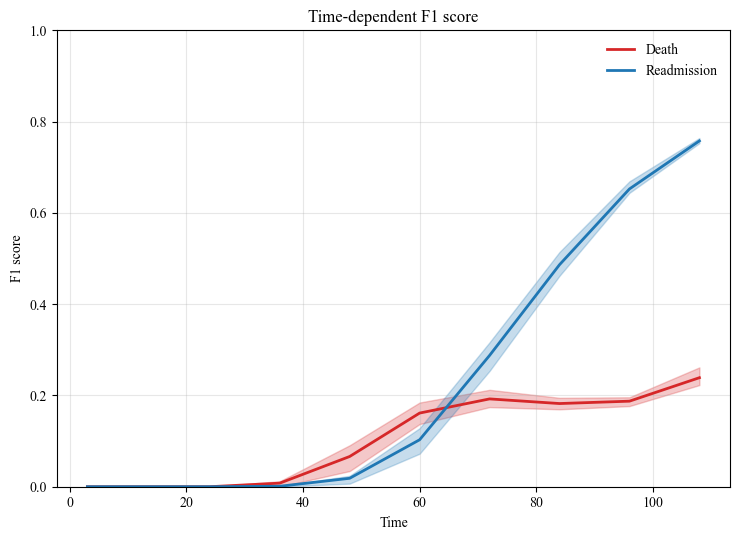

```
💾 Saved: dh3\DH3_F1_20260209_1600.png
💾 Saved: dh3\DH3_F1_20260209_1600.pdf
```

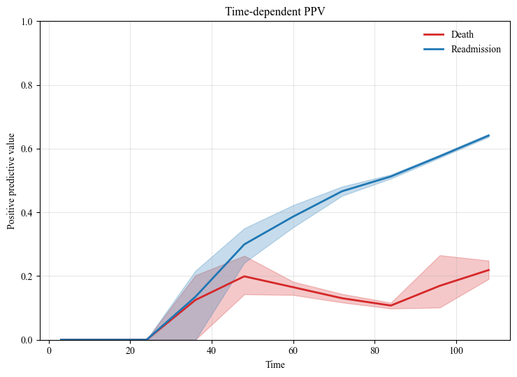

```
💾 Saved: dh3\DH3_PPV_20260209_1600.png
💾 Saved: dh3\DH3_PPV_20260209_1600.pdf
```

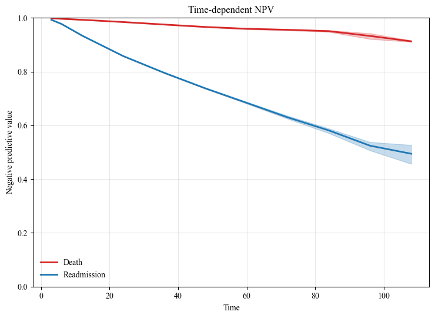

```
💾 Saved: dh3\DH3_NPV_20260209_1600.png
💾 Saved: dh3\DH3_NPV_20260209_1600.pdf
```

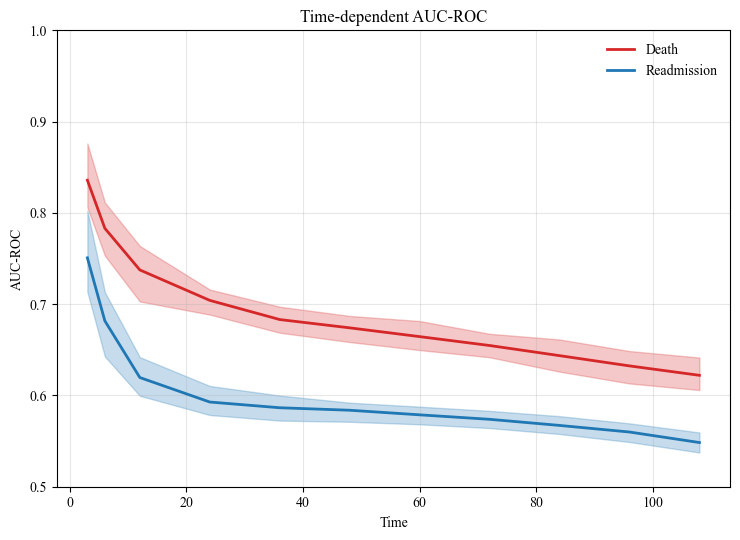

```
💾 Saved: dh3\DH3_AUC-ROC_20260209_1600.png
💾 Saved: dh3\DH3_AUC-ROC_20260209_1600.pdf
```

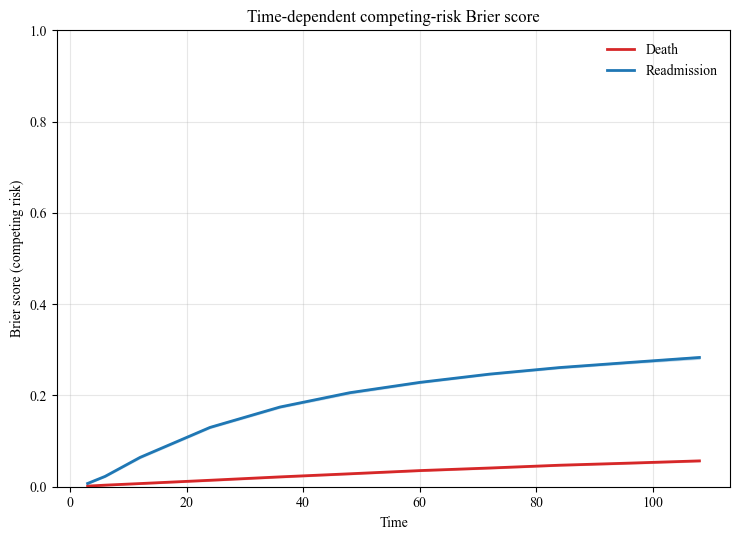

```
💾 Saved: dh3\DH3_Brier Score (CR)_20260209_1600.png
💾 Saved: dh3\DH3_Brier Score (CR)_20260209_1600.pdf
```

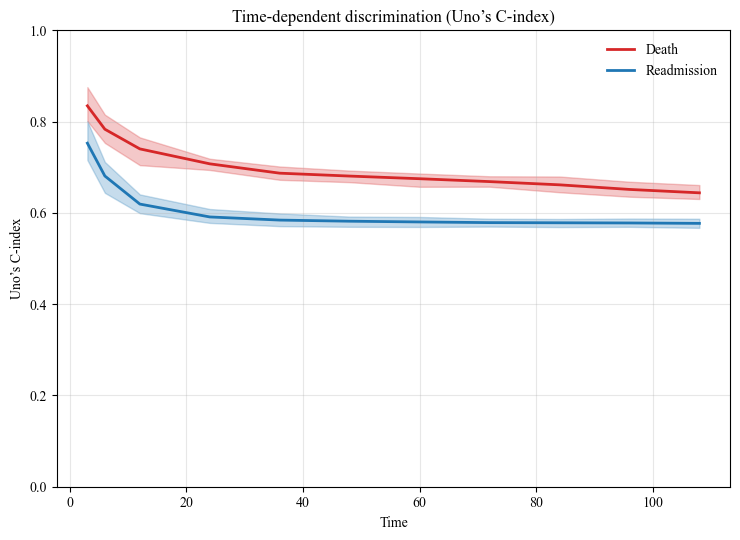

```
💾 Saved: dh3\DH3_Uno C-Index_20260209_1600.png
💾 Saved: dh3\DH3_Uno C-Index_20260209_1600.pdf
```

```python
import os
import numpy as np
import matplotlib.pyplot as plt
from datetime import datetime

def plot_time_metric_joint(
    df_res,
    metric,
    ylabel=None,
    title=None,
    colors={"Death": "tab:red", "Readmission": "tab:blue"},
    band_alpha=0.25,
    ylim=(0, 1),
    outdir="dh3"
):
    # --- timestamp ---
    timestamp = datetime.now().strftime("%Y%m%d_%H%M")

    # --- create output folder ---
    os.makedirs(outdir, exist_ok=True)

    plt.figure(figsize=(7.5, 5.5))

    for outcome, color in colors.items():
        dfp = (
            df_res
            .loc[
                (df_res["Metric"] == metric) &
                (df_res["Outcome"] == outcome) &
                (df_res["Time"] != "Global")
            ]
            .groupby("Time")["Value"]
            .agg(
                mean="mean",
                q25=lambda x: np.percentile(x, 25),
                q75=lambda x: np.percentile(x, 75),
            )
            .reset_index()
            .sort_values("Time")
        )

        if dfp.empty:
            continue

        plt.plot(
            dfp["Time"],
            dfp["mean"],
            color=color,
            linewidth=2,
            label=outcome
        )
        plt.fill_between(
            dfp["Time"],
            dfp["q25"],
            dfp["q75"],
            color=color,
            alpha=band_alpha
        )

    plt.xlabel("Time")
    plt.ylabel(ylabel if ylabel else metric)
    plt.title(title if title else f"Time-dependent {metric}")
    plt.ylim(*ylim)
    plt.legend(frameon=False)
    plt.grid(True, alpha=0.3)
    plt.tight_layout()

    # --- filenames ---
    base = f"DH3_{metric}_{timestamp}"
    png_path = os.path.join(outdir, f"{base}.png")
    pdf_path = os.path.join(outdir, f"{base}.pdf")

    # --- save ---
    plt.savefig(png_path, dpi=300, bbox_inches="tight")
    plt.savefig(pdf_path, bbox_inches="tight")
    plt.show()
    plt.close()

    print(f"💾 Saved: {png_path}")
    print(f"💾 Saved: {pdf_path}")


plot_time_metric_joint(
    df_res,
    metric="F1",
    ylabel="F1 score",
    title="Time-dependent F1 score",
    ylim=(0, 1)
)
plot_time_metric_joint(
    df_res,
    metric="PPV",
    ylabel="Positive predictive value",
    title="Time-dependent PPV",
    ylim=(0, 1)
)
plot_time_metric_joint(
    df_res,
    metric="NPV",
    ylabel="Negative predictive value",
    title="Time-dependent NPV",
    ylim=(0, 1)
)
plot_time_metric_joint(
    df_res,
    metric="AUC-ROC",
    ylabel="AUC-ROC",
    title="Time-dependent AUC-ROC",
    ylim=(0.5, 1)
)
plot_time_metric_joint(
    df_res=df_res,
    metric="Brier Score (CR)",
    ylabel="Brier score (competing risk)",
    title="Time-dependent competing-risk Brier score"
)
plot_time_metric_joint(
    df_res=df_res,
    metric="Uno C-Index",
    ylabel="Uno’s C-index",
    title="Time-dependent discrimination (Uno’s C-index)"
)
```